# Risk Factor Analysis

## Outcome Variable

**Outcome Variable:** ever_swasted

## Predictor Variables

**Intervention Variable:** mbmi

**Adjustment Set:**

- arm
- W_mage
- meducyrs
- feducyrs
- hhwealth_quart
- W_nchldlt5
- brthmon
- W_parity
- delta_W_mage
- delta_meducyrs
- delta_feducyrs
- delta_hhwealth_quart
- delta_W_nchldlt5
- delta_brthmon
- delta_W_parity

## Stratifying Variables

The analysis was stratified on these variable(s):

- agecat
- studyid
- country

## Data Summary

| agecat | studyid | country | mbmi | ever_swasted | n_cell | n |
| --- | --- | --- | --- | --- | --- | --- |
| 0-24 months | ki0047075b-MAL-ED | BANGLADESH | Normal weight | 0 | 209 | 254 |
| 0-24 months | ki0047075b-MAL-ED | BANGLADESH | Normal weight | 1 | 13 | 254 |
| 0-24 months | ki0047075b-MAL-ED | BANGLADESH | Underweight | 0 | 24 | 254 |
| 0-24 months | ki0047075b-MAL-ED | BANGLADESH | Underweight | 1 | 8 | 254 |
| 0-24 months | ki0047075b-MAL-ED | BRAZIL | Normal weight | 0 | 207 | 221 |
| 0-24 months | ki0047075b-MAL-ED | BRAZIL | Normal weight | 1 | 4 | 221 |
| 0-24 months | ki0047075b-MAL-ED | BRAZIL | Underweight | 0 | 10 | 221 |
| 0-24 months | ki0047075b-MAL-ED | BRAZIL | Underweight | 1 | 0 | 221 |
| 0-24 months | ki0047075b-MAL-ED | INDIA | Normal weight | 0 | 175 | 242 |
| 0-24 months | ki0047075b-MAL-ED | INDIA | Normal weight | 1 | 18 | 242 |
| 0-24 months | ki0047075b-MAL-ED | INDIA | Underweight | 0 | 41 | 242 |
| 0-24 months | ki0047075b-MAL-ED | INDIA | Underweight | 1 | 8 | 242 |
| 0-24 months | ki0047075b-MAL-ED | NEPAL | Normal weight | 0 | 229 | 238 |
| 0-24 months | ki0047075b-MAL-ED | NEPAL | Normal weight | 1 | 9 | 238 |
| 0-24 months | ki0047075b-MAL-ED | NEPAL | Underweight | 0 | 0 | 238 |
| 0-24 months | ki0047075b-MAL-ED | NEPAL | Underweight | 1 | 0 | 238 |
| 0-24 months | ki0047075b-MAL-ED | PERU | Normal weight | 0 | 281 | 290 |
| 0-24 months | ki0047075b-MAL-ED | PERU | Normal weight | 1 | 4 | 290 |
| 0-24 months | ki0047075b-MAL-ED | PERU | Underweight | 0 | 5 | 290 |
| 0-24 months | ki0047075b-MAL-ED | PERU | Underweight | 1 | 0 | 290 |
| 0-24 months | ki0047075b-MAL-ED | SOUTH AFRICA | Normal weight | 0 | 247 | 270 |
| 0-24 months | ki0047075b-MAL-ED | SOUTH AFRICA | Normal weight | 1 | 15 | 270 |
| 0-24 months | ki0047075b-MAL-ED | SOUTH AFRICA | Underweight | 0 | 8 | 270 |
| 0-24 months | ki0047075b-MAL-ED | SOUTH AFRICA | Underweight | 1 | 0 | 270 |
| 0-24 months | ki0047075b-MAL-ED | TANZANIA, UNITED REPUBLIC OF | Normal weight | 0 | 234 | 256 |
| 0-24 months | ki0047075b-MAL-ED | TANZANIA, UNITED REPUBLIC OF | Normal weight | 1 | 8 | 256 |
| 0-24 months | ki0047075b-MAL-ED | TANZANIA, UNITED REPUBLIC OF | Underweight | 0 | 13 | 256 |
| 0-24 months | ki0047075b-MAL-ED | TANZANIA, UNITED REPUBLIC OF | Underweight | 1 | 1 | 256 |
| 0-24 months | ki1000304b-SAS-CompFeed | INDIA | Normal weight | 0 | 899 | 1390 |
| 0-24 months | ki1000304b-SAS-CompFeed | INDIA | Normal weight | 1 | 120 | 1390 |

[output cut: 170 more lines]

The following strata were considered:

- agecat: 0-24 months, studyid: ki0047075b-MAL-ED, country: BANGLADESH
- agecat: 0-24 months, studyid: ki0047075b-MAL-ED, country: BRAZIL
- agecat: 0-24 months, studyid: ki0047075b-MAL-ED, country: INDIA
- agecat: 0-24 months, studyid: ki0047075b-MAL-ED, country: NEPAL
- agecat: 0-24 months, studyid: ki0047075b-MAL-ED, country: PERU
- agecat: 0-24 months, studyid: ki0047075b-MAL-ED, country: SOUTH AFRICA
- agecat: 0-24 months, studyid: ki0047075b-MAL-ED, country: TANZANIA, UNITED REPUBLIC OF
- agecat: 0-24 months, studyid: ki1000304b-SAS-CompFeed, country: INDIA
- agecat: 0-24 months, studyid: ki1017093-NIH-Birth, country: BANGLADESH
- agecat: 0-24 months, studyid: ki1017093b-PROVIDE, country: BANGLADESH
- agecat: 0-24 months, studyid: ki1017093c-NIH-Crypto, country: BANGLADESH
- agecat: 0-24 months, studyid: ki1066203-TanzaniaChild2, country: TANZANIA, UNITED REPUBLIC OF
- agecat: 0-24 months, studyid: ki1112895-iLiNS-Zinc, country: BURKINA FASO
- agecat: 0-24 months, studyid: ki1119695-PROBIT, country: BELARUS
- agecat: 0-24 months, studyid: ki1126311-ZVITAMBO, country: ZIMBABWE
- agecat: 0-24 months, studyid: ki1148112-LCNI-5, country: MALAWI
- agecat: 0-24 months, studyid: kiGH5241-JiVitA-3, country: BANGLADESH
- agecat: 0-6 months, studyid: ki0047075b-MAL-ED, country: BANGLADESH
- agecat: 0-6 months, studyid: ki0047075b-MAL-ED, country: BRAZIL
- agecat: 0-6 months, studyid: ki0047075b-MAL-ED, country: INDIA
- agecat: 0-6 months, studyid: ki0047075b-MAL-ED, country: NEPAL
- agecat: 0-6 months, studyid: ki0047075b-MAL-ED, country: PERU
- agecat: 0-6 months, studyid: ki0047075b-MAL-ED, country: SOUTH AFRICA
- agecat: 0-6 months, studyid: ki0047075b-MAL-ED, country: TANZANIA, UNITED REPUBLIC OF
- agecat: 0-6 months, studyid: ki1000304b-SAS-CompFeed, country: INDIA
- agecat: 0-6 months, studyid: ki1017093-NIH-Birth, country: BANGLADESH
- agecat: 0-6 months, studyid: ki1017093b-PROVIDE, country: BANGLADESH
- agecat: 0-6 months, studyid: ki1017093c-NIH-Crypto, country: BANGLADESH
- agecat: 0-6 months, studyid: ki1066203-TanzaniaChild2, country: TANZANIA, UNITED REPUBLIC OF
- agecat: 0-6 months, studyid: ki1119695-PROBIT, country: BELARUS
- agecat: 0-6 months, studyid: ki1126311-ZVITAMBO, country: ZIMBABWE
- agecat: 0-6 months, studyid: ki1148112-LCNI-5, country: MALAWI
- agecat: 0-6 months, studyid: kiGH5241-JiVitA-3, country: BANGLADESH
- agecat: 6-24 months, studyid: ki0047075b-MAL-ED, country: BANGLADESH
- agecat: 6-24 months, studyid: ki0047075b-MAL-ED, country: BRAZIL
- agecat: 6-24 months, studyid: ki0047075b-MAL-ED, country: INDIA
- agecat: 6-24 months, studyid: ki0047075b-MAL-ED, country: NEPAL
- agecat: 6-24 months, studyid: ki0047075b-MAL-ED, country: PERU
- agecat: 6-24 months, studyid: ki0047075b-MAL-ED, country: SOUTH AFRICA
- agecat: 6-24 months, studyid: ki0047075b-MAL-ED, country: TANZANIA, UNITED REPUBLIC OF
- agecat: 6-24 months, studyid: ki1000304b-SAS-CompFeed, country: INDIA
- agecat: 6-24 months, studyid: ki1017093-NIH-Birth, country: BANGLADESH
- agecat: 6-24 months, studyid: ki1017093b-PROVIDE, country: BANGLADESH
- agecat: 6-24 months, studyid: ki1017093c-NIH-Crypto, country: BANGLADESH
- agecat: 6-24 months, studyid: ki1066203-TanzaniaChild2, country: TANZANIA, UNITED REPUBLIC OF
- agecat: 6-24 months, studyid: ki1112895-iLiNS-Zinc, country: BURKINA FASO
- agecat: 6-24 months, studyid: ki1119695-PROBIT, country: BELARUS
- agecat: 6-24 months, studyid: ki1126311-ZVITAMBO, country: ZIMBABWE
- agecat: 6-24 months, studyid: ki1148112-LCNI-5, country: MALAWI
- agecat: 6-24 months, studyid: kiGH5241-JiVitA-3, country: BANGLADESH

### Dropped Strata

Some strata were dropped due to rare outcomes:

- agecat: 0-24 months, studyid: ki0047075b-MAL-ED, country: BRAZIL
- agecat: 0-24 months, studyid: ki0047075b-MAL-ED, country: NEPAL
- agecat: 0-24 months, studyid: ki0047075b-MAL-ED, country: PERU
- agecat: 0-24 months, studyid: ki0047075b-MAL-ED, country: SOUTH AFRICA
- agecat: 0-24 months, studyid: ki0047075b-MAL-ED, country: TANZANIA, UNITED REPUBLIC OF
- agecat: 0-24 months, studyid: ki1066203-TanzaniaChild2, country: TANZANIA, UNITED REPUBLIC OF
- agecat: 0-24 months, studyid: ki1148112-LCNI-5, country: MALAWI
- agecat: 0-6 months, studyid: ki0047075b-MAL-ED, country: BRAZIL
- agecat: 0-6 months, studyid: ki0047075b-MAL-ED, country: NEPAL
- agecat: 0-6 months, studyid: ki0047075b-MAL-ED, country: PERU
- agecat: 0-6 months, studyid: ki0047075b-MAL-ED, country: SOUTH AFRICA
- agecat: 0-6 months, studyid: ki0047075b-MAL-ED, country: TANZANIA, UNITED REPUBLIC OF
- agecat: 0-6 months, studyid: ki1066203-TanzaniaChild2, country: TANZANIA, UNITED REPUBLIC OF
- agecat: 0-6 months, studyid: ki1148112-LCNI-5, country: MALAWI
- agecat: 6-24 months, studyid: ki0047075b-MAL-ED, country: BANGLADESH
- agecat: 6-24 months, studyid: ki0047075b-MAL-ED, country: BRAZIL
- agecat: 6-24 months, studyid: ki0047075b-MAL-ED, country: INDIA
- agecat: 6-24 months, studyid: ki0047075b-MAL-ED, country: NEPAL
- agecat: 6-24 months, studyid: ki0047075b-MAL-ED, country: PERU
- agecat: 6-24 months, studyid: ki0047075b-MAL-ED, country: SOUTH AFRICA
- agecat: 6-24 months, studyid: ki0047075b-MAL-ED, country: TANZANIA, UNITED REPUBLIC OF
- agecat: 6-24 months, studyid: ki1017093b-PROVIDE, country: BANGLADESH
- agecat: 6-24 months, studyid: ki1066203-TanzaniaChild2, country: TANZANIA, UNITED REPUBLIC OF
- agecat: 6-24 months, studyid: ki1119695-PROBIT, country: BELARUS
- agecat: 6-24 months, studyid: ki1148112-LCNI-5, country: MALAWI

## Methods Detail

We’re interested in the causal parameters $E[Y_a]$ for all values of $a \in \mathcal{A}$. These parameters represent the mean outcome if, possibly contrary to fact, we intervened to set all units to have $A=a$. Under the randomization and positivity assumptions, these are identified by the statistical parameters $\psi_a=E_W[E_{Y|A,W}(Y|A=a,W)]$. In addition, we’re interested in the mean of $Y$, $E[Y]$ under no intervention (the observed mean). We will estimate these parameters by using SuperLearner to fit the relevant likelihood factors – $E_{Y|A,W}(Y|A=a,W)$ and $p(A=a|W)$, and then updating our likelihood fit using a joint TMLE.

For unadjusted analyses ($W=\{\}$), initial likelihoods were estimated using Lrnr_glm to estimate the simple $E(Y|A)$ and Lrnr_mean to estimate $p(A)$. For adjusted analyses, a small library containing Lrnr_glmnet, Lrnr_xgboost, and Lrnr_mean was used.

Having estimated these parameters, we will then use the delta method to estimate relative risks and attributable risks relative to a prespecified baseline level of $A$.

# Results Detail

## Results Plots

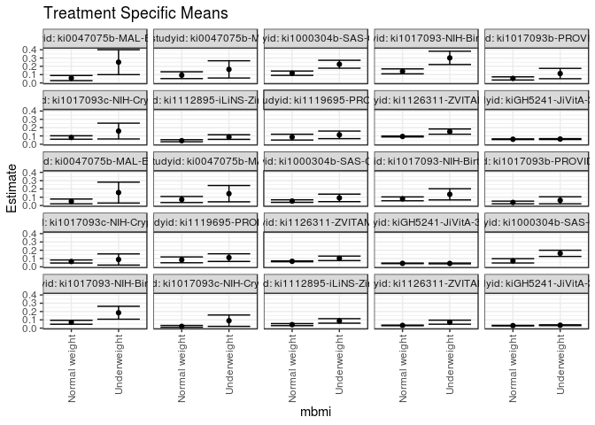

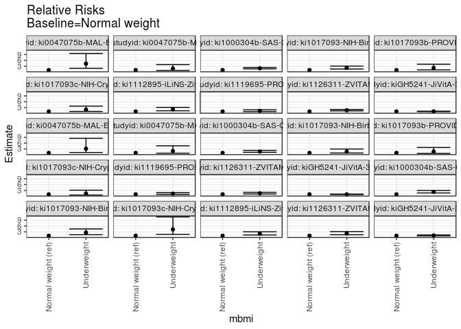

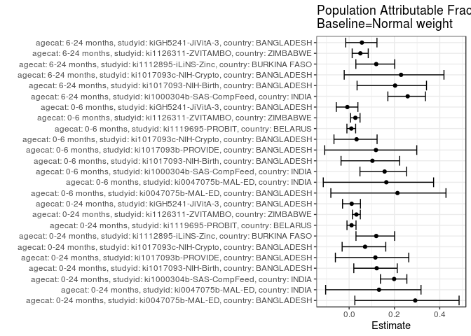

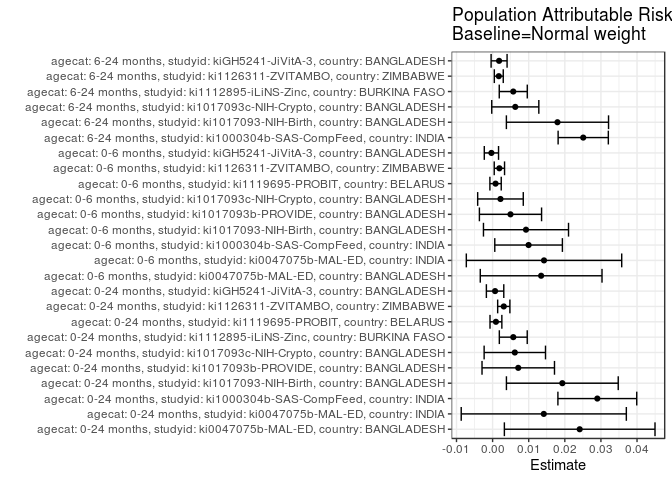

## Results Table

### Parameter: TSM

| agecat | studyid | country | intervention_level | baseline_level | estimate | ci_lower | ci_upper |
| --- | --- | --- | --- | --- | --- | --- | --- |
| 0-24 months | ki0047075b-MAL-ED | BANGLADESH | Normal weight | NA | 0.0585586 | 0.0276115 | 0.0895057 |
| 0-24 months | ki0047075b-MAL-ED | BANGLADESH | Underweight | NA | 0.2500000 | 0.0996753 | 0.4003247 |
| 0-24 months | ki0047075b-MAL-ED | INDIA | Normal weight | NA | 0.0932642 | 0.0521524 | 0.1343761 |
| 0-24 months | ki0047075b-MAL-ED | INDIA | Underweight | NA | 0.1632653 | 0.0595626 | 0.2669680 |
| 0-24 months | ki1000304b-SAS-CompFeed | INDIA | Normal weight | NA | 0.1170399 | 0.0910293 | 0.1430505 |
| 0-24 months | ki1000304b-SAS-CompFeed | INDIA | Underweight | NA | 0.2251129 | 0.1771500 | 0.2730758 |
| 0-24 months | ki1017093-NIH-Birth | BANGLADESH | Normal weight | NA | 0.1393422 | 0.1095514 | 0.1691330 |
| 0-24 months | ki1017093-NIH-Birth | BANGLADESH | Underweight | NA | 0.3016427 | 0.2217315 | 0.3815539 |
| 0-24 months | ki1017093b-PROVIDE | BANGLADESH | Normal weight | NA | 0.0541812 | 0.0350957 | 0.0732668 |
| 0-24 months | ki1017093b-PROVIDE | BANGLADESH | Underweight | NA | 0.1130133 | 0.0509766 | 0.1750500 |
| 0-24 months | ki1017093c-NIH-Crypto | BANGLADESH | Normal weight | NA | 0.0812643 | 0.0605970 | 0.1019317 |
| 0-24 months | ki1017093c-NIH-Crypto | BANGLADESH | Underweight | NA | 0.1585400 | 0.0632013 | 0.2538786 |
| 0-24 months | ki1112895-iLiNS-Zinc | BURKINA FASO | Normal weight | NA | 0.0421442 | 0.0296946 | 0.0545937 |
| 0-24 months | ki1112895-iLiNS-Zinc | BURKINA FASO | Underweight | NA | 0.0867307 | 0.0587173 | 0.1147441 |
| 0-24 months | ki1119695-PROBIT | BELARUS | Normal weight | NA | 0.0855446 | 0.0505257 | 0.1205634 |
| 0-24 months | ki1119695-PROBIT | BELARUS | Underweight | NA | 0.1128709 | 0.0671329 | 0.1586089 |
| 0-24 months | ki1126311-ZVITAMBO | ZIMBABWE | Normal weight | NA | 0.0933631 | 0.0874395 | 0.0992867 |
| 0-24 months | ki1126311-ZVITAMBO | ZIMBABWE | Underweight | NA | 0.1521544 | 0.1206199 | 0.1836889 |
| 0-24 months | kiGH5241-JiVitA-3 | BANGLADESH | Normal weight | NA | 0.0603156 | 0.0561717 | 0.0644595 |
| 0-24 months | kiGH5241-JiVitA-3 | BANGLADESH | Underweight | NA | 0.0621331 | 0.0567658 | 0.0675005 |
| 0-6 months | ki0047075b-MAL-ED | BANGLADESH | Normal weight | NA | 0.0495495 | 0.0209465 | 0.0781526 |
| 0-6 months | ki0047075b-MAL-ED | BANGLADESH | Underweight | NA | 0.1562500 | 0.0301989 | 0.2823011 |
| 0-6 months | ki0047075b-MAL-ED | INDIA | Normal weight | NA | 0.0725389 | 0.0358696 | 0.1092081 |
| 0-6 months | ki0047075b-MAL-ED | INDIA | Underweight | NA | 0.1428571 | 0.0446763 | 0.2410380 |
| 0-6 months | ki1000304b-SAS-CompFeed | INDIA | Normal weight | NA | 0.0536634 | 0.0383046 | 0.0690222 |
| 0-6 months | ki1000304b-SAS-CompFeed | INDIA | Underweight | NA | 0.0919779 | 0.0468456 | 0.1371102 |
| 0-6 months | ki1017093-NIH-Birth | BANGLADESH | Normal weight | NA | 0.0807842 | 0.0572918 | 0.1042767 |
| 0-6 months | ki1017093-NIH-Birth | BANGLADESH | Underweight | NA | 0.1348900 | 0.0674507 | 0.2023293 |
| 0-6 months | ki1017093b-PROVIDE | BANGLADESH | Normal weight | NA | 0.0369004 | 0.0210177 | 0.0527831 |
| 0-6 months | ki1017093b-PROVIDE | BANGLADESH | Underweight | NA | 0.0629921 | 0.0207072 | 0.1052771 |
| 0-6 months | ki1017093c-NIH-Crypto | BANGLADESH | Normal weight | NA | 0.0640466 | 0.0457263 | 0.0823669 |
| 0-6 months | ki1017093c-NIH-Crypto | BANGLADESH | Underweight | NA | 0.0882353 | 0.0207757 | 0.1556949 |
| 0-6 months | ki1119695-PROBIT | BELARUS | Normal weight | NA | 0.0842604 | 0.0491528 | 0.1193679 |
| 0-6 months | ki1119695-PROBIT | BELARUS | Underweight | NA | 0.1111324 | 0.0650300 | 0.1572348 |
| 0-6 months | ki1126311-ZVITAMBO | ZIMBABWE | Normal weight | NA | 0.0664611 | 0.0613794 | 0.0715428 |
| 0-6 months | ki1126311-ZVITAMBO | ZIMBABWE | Underweight | NA | 0.1021139 | 0.0749758 | 0.1292520 |
| 0-6 months | kiGH5241-JiVitA-3 | BANGLADESH | Normal weight | NA | 0.0416910 | 0.0382067 | 0.0451754 |
| 0-6 months | kiGH5241-JiVitA-3 | BANGLADESH | Underweight | NA | 0.0407802 | 0.0362791 | 0.0452812 |
| 6-24 months | ki1000304b-SAS-CompFeed | INDIA | Normal weight | NA | 0.0720040 | 0.0461785 | 0.0978295 |
| 6-24 months | ki1000304b-SAS-CompFeed | INDIA | Underweight | NA | 0.1624711 | 0.1252003 | 0.1997420 |
| 6-24 months | ki1017093-NIH-Birth | BANGLADESH | Normal weight | NA | 0.0705970 | 0.0467821 | 0.0944120 |
| 6-24 months | ki1017093-NIH-Birth | BANGLADESH | Underweight | NA | 0.1853050 | 0.1075520 | 0.2630581 |
| 6-24 months | ki1017093c-NIH-Crypto | BANGLADESH | Normal weight | NA | 0.0211161 | 0.0101649 | 0.0320673 |
| 6-24 months | ki1017093c-NIH-Crypto | BANGLADESH | Underweight | NA | 0.0895522 | 0.0211337 | 0.1579708 |
| 6-24 months | ki1112895-iLiNS-Zinc | BURKINA FASO | Normal weight | NA | 0.0421476 | 0.0296730 | 0.0546221 |
| 6-24 months | ki1112895-iLiNS-Zinc | BURKINA FASO | Underweight | NA | 0.0866932 | 0.0595352 | 0.1138512 |
| 6-24 months | ki1126311-ZVITAMBO | ZIMBABWE | Normal weight | NA | 0.0328348 | 0.0289576 | 0.0367121 |
| 6-24 months | ki1126311-ZVITAMBO | ZIMBABWE | Underweight | NA | 0.0715037 | 0.0471221 | 0.0958852 |
| 6-24 months | kiGH5241-JiVitA-3 | BANGLADESH | Normal weight | NA | 0.0300946 | 0.0266364 | 0.0335528 |
| 6-24 months | kiGH5241-JiVitA-3 | BANGLADESH | Underweight | NA | 0.0348264 | 0.0300057 | 0.0396471 |

### Parameter: E(Y)

| agecat | studyid | country | intervention_level | baseline_level | estimate | ci_lower | ci_upper |
| --- | --- | --- | --- | --- | --- | --- | --- |
| 0-24 months | ki0047075b-MAL-ED | BANGLADESH | NA | NA | 0.0826772 | 0.0487426 | 0.1166117 |
| 0-24 months | ki0047075b-MAL-ED | INDIA | NA | NA | 0.1074380 | 0.0683415 | 0.1465345 |
| 0-24 months | ki1000304b-SAS-CompFeed | INDIA | NA | NA | 0.1460432 | 0.1145875 | 0.1774988 |
| 0-24 months | ki1017093-NIH-Birth | BANGLADESH | NA | NA | 0.1586538 | 0.1299648 | 0.1873429 |
| 0-24 months | ki1017093b-PROVIDE | BANGLADESH | NA | NA | 0.0612855 | 0.0430966 | 0.0794744 |
| 0-24 months | ki1017093c-NIH-Crypto | BANGLADESH | NA | NA | 0.0874172 | 0.0672569 | 0.1075775 |
| 0-24 months | ki1112895-iLiNS-Zinc | BURKINA FASO | NA | NA | 0.0478707 | 0.0359037 | 0.0598376 |
| 0-24 months | ki1119695-PROBIT | BELARUS | NA | NA | 0.0864656 | 0.0516689 | 0.1212624 |
| 0-24 months | ki1126311-ZVITAMBO | ZIMBABWE | NA | NA | 0.0964581 | 0.0906120 | 0.1023042 |
| 0-24 months | kiGH5241-JiVitA-3 | BANGLADESH | NA | NA | 0.0610001 | 0.0575046 | 0.0644957 |
| 0-6 months | ki0047075b-MAL-ED | BANGLADESH | NA | NA | 0.0629921 | 0.0330555 | 0.0929287 |
| 0-6 months | ki0047075b-MAL-ED | INDIA | NA | NA | 0.0867769 | 0.0512358 | 0.1223179 |
| 0-6 months | ki1000304b-SAS-CompFeed | INDIA | NA | NA | 0.0636298 | 0.0408673 | 0.0863923 |
| 0-6 months | ki1017093-NIH-Birth | BANGLADESH | NA | NA | 0.0900322 | 0.0675202 | 0.1125442 |
| 0-6 months | ki1017093b-PROVIDE | BANGLADESH | NA | NA | 0.0418535 | 0.0266676 | 0.0570395 |
| 0-6 months | ki1017093c-NIH-Crypto | BANGLADESH | NA | NA | 0.0662252 | 0.0484753 | 0.0839750 |
| 0-6 months | ki1119695-PROBIT | BELARUS | NA | NA | 0.0850816 | 0.0501716 | 0.1199915 |
| 0-6 months | ki1126311-ZVITAMBO | ZIMBABWE | NA | NA | 0.0683402 | 0.0633339 | 0.0733464 |
| 0-6 months | kiGH5241-JiVitA-3 | BANGLADESH | NA | NA | 0.0413628 | 0.0383754 | 0.0443502 |
| 6-24 months | ki1000304b-SAS-CompFeed | INDIA | NA | NA | 0.0971026 | 0.0697212 | 0.1244840 |
| 6-24 months | ki1017093-NIH-Birth | BANGLADESH | NA | NA | 0.0885609 | 0.0646203 | 0.1125014 |
| 6-24 months | ki1017093c-NIH-Crypto | BANGLADESH | NA | NA | 0.0273973 | 0.0155476 | 0.0392469 |
| 6-24 months | ki1112895-iLiNS-Zinc | BURKINA FASO | NA | NA | 0.0478707 | 0.0359037 | 0.0598376 |
| 6-24 months | ki1126311-ZVITAMBO | ZIMBABWE | NA | NA | 0.0345469 | 0.0306862 | 0.0384077 |
| 6-24 months | kiGH5241-JiVitA-3 | BANGLADESH | NA | NA | 0.0318915 | 0.0289933 | 0.0347896 |

### Parameter: RR

| agecat | studyid | country | intervention_level | baseline_level | estimate | ci_lower | ci_upper |
| --- | --- | --- | --- | --- | --- | --- | --- |
| 0-24 months | ki0047075b-MAL-ED | BANGLADESH | Normal weight | Normal weight | 1.0000000 | 1.0000000 | 1.000000 |
| 0-24 months | ki0047075b-MAL-ED | BANGLADESH | Underweight | Normal weight | 4.2692308 | 1.9172672 | 9.506412 |
| 0-24 months | ki0047075b-MAL-ED | INDIA | Normal weight | Normal weight | 1.0000000 | 1.0000000 | 1.000000 |
| 0-24 months | ki0047075b-MAL-ED | INDIA | Underweight | Normal weight | 1.7505669 | 0.8079836 | 3.792756 |
| 0-24 months | ki1000304b-SAS-CompFeed | INDIA | Normal weight | Normal weight | 1.0000000 | 1.0000000 | 1.000000 |
| 0-24 months | ki1000304b-SAS-CompFeed | INDIA | Underweight | Normal weight | 1.9233856 | 1.6072582 | 2.301691 |
| 0-24 months | ki1017093-NIH-Birth | BANGLADESH | Normal weight | Normal weight | 1.0000000 | 1.0000000 | 1.000000 |
| 0-24 months | ki1017093-NIH-Birth | BANGLADESH | Underweight | Normal weight | 2.1647618 | 1.5417636 | 3.039502 |
| 0-24 months | ki1017093b-PROVIDE | BANGLADESH | Normal weight | Normal weight | 1.0000000 | 1.0000000 | 1.000000 |
| 0-24 months | ki1017093b-PROVIDE | BANGLADESH | Underweight | Normal weight | 2.0858377 | 1.0859356 | 4.006424 |
| 0-24 months | ki1017093c-NIH-Crypto | BANGLADESH | Normal weight | Normal weight | 1.0000000 | 1.0000000 | 1.000000 |
| 0-24 months | ki1017093c-NIH-Crypto | BANGLADESH | Underweight | Normal weight | 1.9509168 | 1.0140181 | 3.753460 |
| 0-24 months | ki1112895-iLiNS-Zinc | BURKINA FASO | Normal weight | Normal weight | 1.0000000 | 1.0000000 | 1.000000 |
| 0-24 months | ki1112895-iLiNS-Zinc | BURKINA FASO | Underweight | Normal weight | 2.0579535 | 1.3592560 | 3.115802 |
| 0-24 months | ki1119695-PROBIT | BELARUS | Normal weight | Normal weight | 1.0000000 | 1.0000000 | 1.000000 |
| 0-24 months | ki1119695-PROBIT | BELARUS | Underweight | Normal weight | 1.3194392 | 0.9344272 | 1.863088 |
| 0-24 months | ki1126311-ZVITAMBO | ZIMBABWE | Normal weight | Normal weight | 1.0000000 | 1.0000000 | 1.000000 |
| 0-24 months | ki1126311-ZVITAMBO | ZIMBABWE | Underweight | Normal weight | 1.6297061 | 1.3120992 | 2.024193 |
| 0-24 months | kiGH5241-JiVitA-3 | BANGLADESH | Normal weight | Normal weight | 1.0000000 | 1.0000000 | 1.000000 |
| 0-24 months | kiGH5241-JiVitA-3 | BANGLADESH | Underweight | Normal weight | 1.0301346 | 0.9297742 | 1.141328 |
| 0-6 months | ki0047075b-MAL-ED | BANGLADESH | Normal weight | Normal weight | 1.0000000 | 1.0000000 | 1.000000 |
| 0-6 months | ki0047075b-MAL-ED | BANGLADESH | Underweight | Normal weight | 3.1534091 | 1.1694063 | 8.503450 |
| 0-6 months | ki0047075b-MAL-ED | INDIA | Normal weight | Normal weight | 1.0000000 | 1.0000000 | 1.000000 |
| 0-6 months | ki0047075b-MAL-ED | INDIA | Underweight | Normal weight | 1.9693878 | 0.8390927 | 4.622240 |
| 0-6 months | ki1000304b-SAS-CompFeed | INDIA | Normal weight | Normal weight | 1.0000000 | 1.0000000 | 1.000000 |
| 0-6 months | ki1000304b-SAS-CompFeed | INDIA | Underweight | Normal weight | 1.7139780 | 1.2871690 | 2.282312 |
| 0-6 months | ki1017093-NIH-Birth | BANGLADESH | Normal weight | Normal weight | 1.0000000 | 1.0000000 | 1.000000 |
| 0-6 months | ki1017093-NIH-Birth | BANGLADESH | Underweight | Normal weight | 1.6697561 | 0.9360159 | 2.978673 |
| 0-6 months | ki1017093b-PROVIDE | BANGLADESH | Normal weight | Normal weight | 1.0000000 | 1.0000000 | 1.000000 |
| 0-6 months | ki1017093b-PROVIDE | BANGLADESH | Underweight | Normal weight | 1.7070866 | 0.7690289 | 3.789382 |
| 0-6 months | ki1017093c-NIH-Crypto | BANGLADESH | Normal weight | Normal weight | 1.0000000 | 1.0000000 | 1.000000 |
| 0-6 months | ki1017093c-NIH-Crypto | BANGLADESH | Underweight | Normal weight | 1.3776738 | 0.6090195 | 3.116460 |
| 0-6 months | ki1119695-PROBIT | BELARUS | Normal weight | Normal weight | 1.0000000 | 1.0000000 | 1.000000 |
| 0-6 months | ki1119695-PROBIT | BELARUS | Underweight | Normal weight | 1.3189169 | 0.9373647 | 1.855779 |
| 0-6 months | ki1126311-ZVITAMBO | ZIMBABWE | Normal weight | Normal weight | 1.0000000 | 1.0000000 | 1.000000 |
| 0-6 months | ki1126311-ZVITAMBO | ZIMBABWE | Underweight | Normal weight | 1.5364465 | 1.1651885 | 2.025997 |
| 0-6 months | kiGH5241-JiVitA-3 | BANGLADESH | Normal weight | Normal weight | 1.0000000 | 1.0000000 | 1.000000 |
| 0-6 months | kiGH5241-JiVitA-3 | BANGLADESH | Underweight | Normal weight | 0.9781523 | 0.8628135 | 1.108909 |
| 6-24 months | ki1000304b-SAS-CompFeed | INDIA | Normal weight | Normal weight | 1.0000000 | 1.0000000 | 1.000000 |
| 6-24 months | ki1000304b-SAS-CompFeed | INDIA | Underweight | Normal weight | 2.2564177 | 1.6989922 | 2.996730 |
| 6-24 months | ki1017093-NIH-Birth | BANGLADESH | Normal weight | Normal weight | 1.0000000 | 1.0000000 | 1.000000 |
| 6-24 months | ki1017093-NIH-Birth | BANGLADESH | Underweight | Normal weight | 2.6248276 | 1.5324919 | 4.495763 |
| 6-24 months | ki1017093c-NIH-Crypto | BANGLADESH | Normal weight | Normal weight | 1.0000000 | 1.0000000 | 1.000000 |
| 6-24 months | ki1017093c-NIH-Crypto | BANGLADESH | Underweight | Normal weight | 4.2409382 | 1.6843541 | 10.678014 |
| 6-24 months | ki1112895-iLiNS-Zinc | BURKINA FASO | Normal weight | Normal weight | 1.0000000 | 1.0000000 | 1.000000 |
| 6-24 months | ki1112895-iLiNS-Zinc | BURKINA FASO | Underweight | Normal weight | 2.0568973 | 1.3933892 | 3.036357 |
| 6-24 months | ki1126311-ZVITAMBO | ZIMBABWE | Normal weight | Normal weight | 1.0000000 | 1.0000000 | 1.000000 |
| 6-24 months | ki1126311-ZVITAMBO | ZIMBABWE | Underweight | Normal weight | 2.1776781 | 1.5179674 | 3.124100 |
| 6-24 months | kiGH5241-JiVitA-3 | BANGLADESH | Normal weight | Normal weight | 1.0000000 | 1.0000000 | 1.000000 |
| 6-24 months | kiGH5241-JiVitA-3 | BANGLADESH | Underweight | Normal weight | 1.1572308 | 0.9719517 | 1.377829 |

### Parameter: PAR

| agecat | studyid | country | intervention_level | baseline_level | estimate | ci_lower | ci_upper |
| --- | --- | --- | --- | --- | --- | --- | --- |
| 0-24 months | ki0047075b-MAL-ED | BANGLADESH | Normal weight | NA | 0.0241186 | 0.0032585 | 0.0449787 |
| 0-24 months | ki0047075b-MAL-ED | INDIA | Normal weight | NA | 0.0141738 | -0.0086912 | 0.0370388 |
| 0-24 months | ki1000304b-SAS-CompFeed | INDIA | Normal weight | NA | 0.0290032 | 0.0180861 | 0.0399204 |
| 0-24 months | ki1017093-NIH-Birth | BANGLADESH | Normal weight | NA | 0.0193116 | 0.0038291 | 0.0347942 |
| 0-24 months | ki1017093b-PROVIDE | BANGLADESH | Normal weight | NA | 0.0071043 | -0.0029311 | 0.0171397 |
| 0-24 months | ki1017093c-NIH-Crypto | BANGLADESH | Normal weight | NA | 0.0061529 | -0.0023461 | 0.0146518 |
| 0-24 months | ki1112895-iLiNS-Zinc | BURKINA FASO | Normal weight | NA | 0.0057265 | 0.0018624 | 0.0095907 |
| 0-24 months | ki1119695-PROBIT | BELARUS | Normal weight | NA | 0.0009210 | -0.0007194 | 0.0025615 |
| 0-24 months | ki1126311-ZVITAMBO | ZIMBABWE | Normal weight | NA | 0.0030950 | 0.0014023 | 0.0047878 |
| 0-24 months | kiGH5241-JiVitA-3 | BANGLADESH | Normal weight | NA | 0.0006846 | -0.0017257 | 0.0030949 |
| 0-6 months | ki0047075b-MAL-ED | BANGLADESH | Normal weight | NA | 0.0134426 | -0.0034159 | 0.0303011 |
| 0-6 months | ki0047075b-MAL-ED | INDIA | Normal weight | NA | 0.0142380 | -0.0072807 | 0.0357567 |
| 0-6 months | ki1000304b-SAS-CompFeed | INDIA | Normal weight | NA | 0.0099664 | 0.0006021 | 0.0193307 |
| 0-6 months | ki1017093-NIH-Birth | BANGLADESH | Normal weight | NA | 0.0092479 | -0.0025307 | 0.0210266 |
| 0-6 months | ki1017093b-PROVIDE | BANGLADESH | Normal weight | NA | 0.0049531 | -0.0036567 | 0.0135629 |
| 0-6 months | ki1017093c-NIH-Crypto | BANGLADESH | Normal weight | NA | 0.0021786 | -0.0041367 | 0.0084939 |
| 0-6 months | ki1119695-PROBIT | BELARUS | Normal weight | NA | 0.0008212 | -0.0007488 | 0.0023913 |
| 0-6 months | ki1126311-ZVITAMBO | ZIMBABWE | Normal weight | NA | 0.0018791 | 0.0004504 | 0.0033077 |
| 0-6 months | kiGH5241-JiVitA-3 | BANGLADESH | Normal weight | NA | -0.0003282 | -0.0023009 | 0.0016444 |
| 6-24 months | ki1000304b-SAS-CompFeed | INDIA | Normal weight | NA | 0.0250986 | 0.0181449 | 0.0320522 |
| 6-24 months | ki1017093-NIH-Birth | BANGLADESH | Normal weight | NA | 0.0179639 | 0.0038173 | 0.0321105 |
| 6-24 months | ki1017093c-NIH-Crypto | BANGLADESH | Normal weight | NA | 0.0062811 | -0.0002381 | 0.0128003 |
| 6-24 months | ki1112895-iLiNS-Zinc | BURKINA FASO | Normal weight | NA | 0.0057231 | 0.0018433 | 0.0096029 |
| 6-24 months | ki1126311-ZVITAMBO | ZIMBABWE | Normal weight | NA | 0.0017121 | 0.0004742 | 0.0029500 |
| 6-24 months | kiGH5241-JiVitA-3 | BANGLADESH | Normal weight | NA | 0.0017968 | -0.0004135 | 0.0040072 |

### Parameter: PAF

| agecat | studyid | country | intervention_level | baseline_level | estimate | ci_lower | ci_upper |
| --- | --- | --- | --- | --- | --- | --- | --- |
| 0-24 months | ki0047075b-MAL-ED | BANGLADESH | Normal weight | NA | 0.2917203 | 0.0252675 | 0.4853356 |
| 0-24 months | ki0047075b-MAL-ED | INDIA | Normal weight | NA | 0.1319251 | -0.1037369 | 0.3172702 |
| 0-24 months | ki1000304b-SAS-CompFeed | INDIA | Normal weight | NA | 0.1985936 | 0.1381627 | 0.2547872 |
| 0-24 months | ki1017093-NIH-Birth | BANGLADESH | Normal weight | NA | 0.1217219 | 0.0206040 | 0.2123999 |
| 0-24 months | ki1017093b-PROVIDE | BANGLADESH | Normal weight | NA | 0.1159207 | -0.0606692 | 0.2631103 |
| 0-24 months | ki1017093c-NIH-Crypto | BANGLADESH | Normal weight | NA | 0.0703853 | -0.0308917 | 0.1617127 |
| 0-24 months | ki1112895-iLiNS-Zinc | BURKINA FASO | Normal weight | NA | 0.1196249 | 0.0302522 | 0.2007610 |
| 0-24 months | ki1119695-PROBIT | BELARUS | Normal weight | NA | 0.0106522 | -0.0094645 | 0.0303679 |
| 0-24 months | ki1126311-ZVITAMBO | ZIMBABWE | Normal weight | NA | 0.0320866 | 0.0144633 | 0.0493947 |
| 0-24 months | kiGH5241-JiVitA-3 | BANGLADESH | Normal weight | NA | 0.0112228 | -0.0290614 | 0.0499300 |
| 0-6 months | ki0047075b-MAL-ED | BANGLADESH | Normal weight | NA | 0.2134009 | -0.0806932 | 0.4274618 |
| 0-6 months | ki0047075b-MAL-ED | INDIA | Normal weight | NA | 0.1640760 | -0.1141862 | 0.3728437 |
| 0-6 months | ki1000304b-SAS-CompFeed | INDIA | Normal weight | NA | 0.1566308 | 0.0477481 | 0.2530637 |
| 0-6 months | ki1017093-NIH-Birth | BANGLADESH | Normal weight | NA | 0.1027178 | -0.0357826 | 0.2226986 |
| 0-6 months | ki1017093b-PROVIDE | BANGLADESH | Normal weight | NA | 0.1183448 | -0.1080833 | 0.2985040 |
| 0-6 months | ki1017093c-NIH-Crypto | BANGLADESH | Normal weight | NA | 0.0328967 | -0.0669351 | 0.1233873 |
| 0-6 months | ki1119695-PROBIT | BELARUS | Normal weight | NA | 0.0096523 | -0.0098078 | 0.0287373 |
| 0-6 months | ki1126311-ZVITAMBO | ZIMBABWE | Normal weight | NA | 0.0274957 | 0.0064497 | 0.0480958 |
| 0-6 months | kiGH5241-JiVitA-3 | BANGLADESH | Normal weight | NA | -0.0079356 | -0.0568119 | 0.0386802 |
| 6-24 months | ki1000304b-SAS-CompFeed | INDIA | Normal weight | NA | 0.2584747 | 0.1709436 | 0.3367644 |
| 6-24 months | ki1017093-NIH-Birth | BANGLADESH | Normal weight | NA | 0.2028419 | 0.0350326 | 0.3414689 |
| 6-24 months | ki1017093c-NIH-Crypto | BANGLADESH | Normal weight | NA | 0.2292609 | -0.0217519 | 0.4186077 |
| 6-24 months | ki1112895-iLiNS-Zinc | BURKINA FASO | Normal weight | NA | 0.1195536 | 0.0296768 | 0.2011056 |
| 6-24 months | ki1126311-ZVITAMBO | ZIMBABWE | Normal weight | NA | 0.0495590 | 0.0134460 | 0.0843500 |
| 6-24 months | kiGH5241-JiVitA-3 | BANGLADESH | Normal weight | NA | 0.0563427 | -0.0152058 | 0.1228486 |